# LBB-R Project Algoritma

Sutanto The

November 4, 2021

# 1 **The Worst Human Error, Titanic**

# 2 **History of Titanic**

RMS Titanic was a British passenger liner operated by the White Star Line that sank in the North Atlantic Ocean on 15 April 1912, after striking an iceberg during her maiden voyage from Southampton to New York City. Of the estimated 2,224 passengers and crew aboard, more than 1,500 died, making the sinking at the time one of the deadliest of a single ship[a] and the deadliest peacetime sinking of a superliner or cruise ship to date.[4] With much public attention in the aftermath, the disaster has since been the material of many artistic works and a founding material of the disaster film genre.

RMS Titanic was the largest ship afloat at the time she entered service and was the second of three Olympic-class ocean liners operated by the White Star Line. She was built by the Harland and Wolff shipyard in Belfast. Thomas Andrews, chief naval architect of the shipyard at the time, died in the disaster.

# 3 **Diving into the Numbers.**

This analysis aims to explore the data on Titanic passengers, based on the data given below.

```r
passenger<- read.csv("test.csv")

str(passenger)
```

```
## 'data.frame':    418 obs. of  11 variables:
##  $ PassengerId: int  892 893 894 895 896 897 898 899 900 901 ...
##  $ Pclass     : int  3 3 2 3 3 3 3 2 3 3 ...
##  $ Name       : chr  "Kelly, Mr. James" "Wilkes, Mrs. James (Ellen Needs)" "Myles, Mr. Thomas Francis" "Wirz, Mr. Albert" ...
##  $ Sex        : chr  "male" "female" "male" "male" ...
##  $ Age        : num  34.5 47 62 27 22 14 30 26 18 21 ...
##  $ SibSp      : int  0 1 0 0 1 0 0 1 0 2 ...
##  $ Parch      : int  0 0 0 0 1 0 0 1 0 0 ...
##  $ Ticket     : chr  "330911" "363272" "240276" "315154" ...
##  $ Fare       : num  7.83 7 9.69 8.66 12.29 ...
##  $ Cabin      : chr  "" "" "" "" ...
##  $ Embarked   : chr  "Q" "S" "Q" "S" ...
```

```r
#Changing data types and checking Nulls on the data
as.factor(passenger$Sex)
```

[output not shown]

[output cut: 28 more lines]

## 3.1 **Data Checking of the Passenger**

```r
summary(passenger)
```

```
##   PassengerId         Pclass          Name               Sex
##  Min.   : 892.0   Min.   :1.000   Length:418         Length:418
##  1st Qu.: 996.2   1st Qu.:1.000   Class :character   Class :character
##  Median :1100.5   Median :3.000   Mode  :character   Mode  :character
##  Mean   :1100.5   Mean   :2.266
##  3rd Qu.:1204.8   3rd Qu.:3.000
##  Max.   :1309.0   Max.   :3.000
##
##       Age            SibSp            Parch           Ticket
##  Min.   : 0.17   Min.   :0.0000   Min.   :0.0000   Length:418
##  1st Qu.:21.00   1st Qu.:0.0000   1st Qu.:0.0000   Class :character
##  Median :27.00   Median :0.0000   Median :0.0000   Mode  :character
##  Mean   :30.27   Mean   :0.4474   Mean   :0.3923
##  3rd Qu.:39.00   3rd Qu.:1.0000   3rd Qu.:0.0000
##  Max.   :76.00   Max.   :8.0000   Max.   :9.0000
##  NA's   :86
##       Fare            Cabin             Embarked
##  Min.   :  0.000   Length:418         Length:418
##  1st Qu.:  7.896   Class :character   Class :character
##  Median : 14.454   Mode  :character   Mode  :character
##  Mean   : 35.627
##  3rd Qu.: 31.500
##  Max.   :512.329
##  NA's   :1
```

## 3.2 **Exploring the crucial Data**

### 3.2.1 **Gender**

```r
table(passenger$Sex)
```

```
##
## female   male
##    152    266
```

```r
passenger$AgeGroup<-ifelse(passenger$Age>0&passenger$Age<=16,"Kids",
                    ifelse(passenger$Age>16&passenger$Age<=25,"Teen",
                    ifelse(passenger$Age>25&passenger$Age<=62,"Adult",
                    ifelse(passenger$Age>62&passenger$Age<=100,"Elderly","NA"))))
```

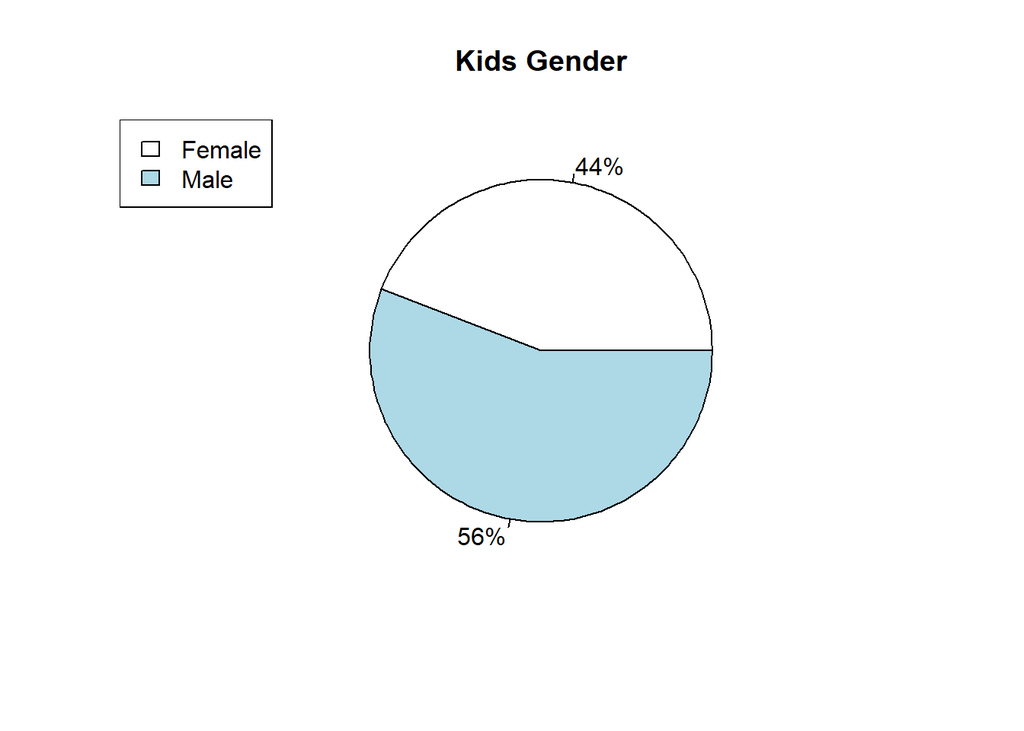

```r
kids<-passenger[passenger$AgeGroup=="Kids",]
teen<-passenger[passenger$AgeGroup=="Teen",]
adult<-passenger[passenger$AgeGroup=="Adult",]
elder<-passenger[passenger$AgeGroup=="Elderly",]

pie(table(kids$Sex),main="Kids Gender",labels=paste0(round(100 * table(kids$Sex)/sum(table(kids$Sex)), 0), "%"))
legend("topleft", legend = c("Female","Male"),fill=c("white","lightblue"))
```

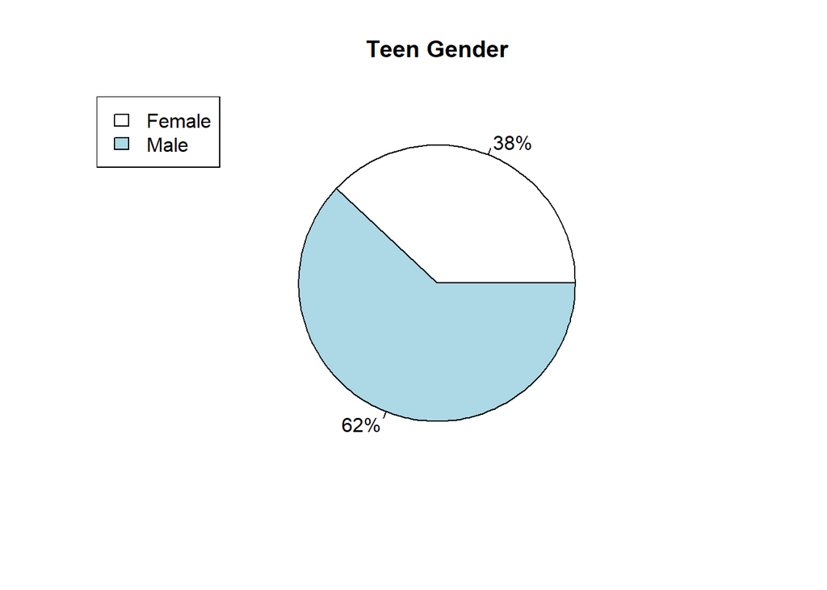

```r
pie(table(teen$Sex),main="Teen Gender",labels=paste0(round(100 * table(teen$Sex)/sum(table(teen$Sex)), 0), "%"))
legend("topleft", legend = c("Female","Male"),fill=c("white","lightblue"))
```

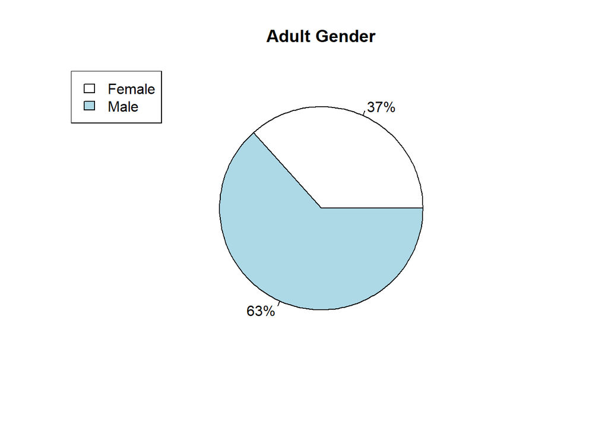

```r
pie(table(adult$Sex),main="Adult Gender",labels=paste0(round(100 * table(adult$Sex)/sum(table(adult$Sex)), 0), "%"))
legend("topleft", legend = c("Female","Male"),fill=c("white","lightblue"))
```

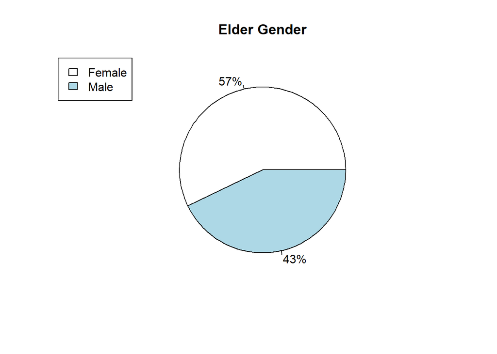

```r
pie(table(elder$Sex),main="Elder Gender",labels=paste0(round(100 * table(elder$Sex)/sum(table(elder$Sex)), 0), "%"))
legend("topleft", legend = c("Female","Male"),fill=c("white","lightblue"))
```

The charts above visualize the distribution of gender based on their age.

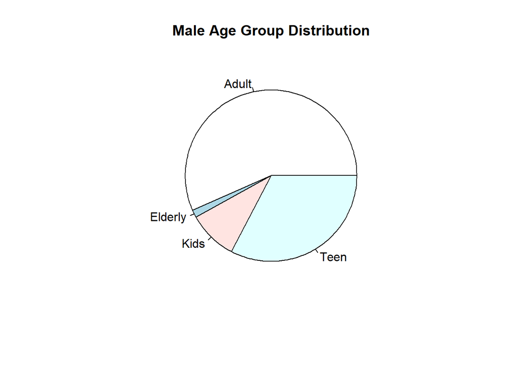

```r
males<-passenger[passenger$Sex=="male",]
females<-passenger[passenger$Sex=="female",]

pie(table(males$AgeGroup),main="Male Age Group Distribution")
```

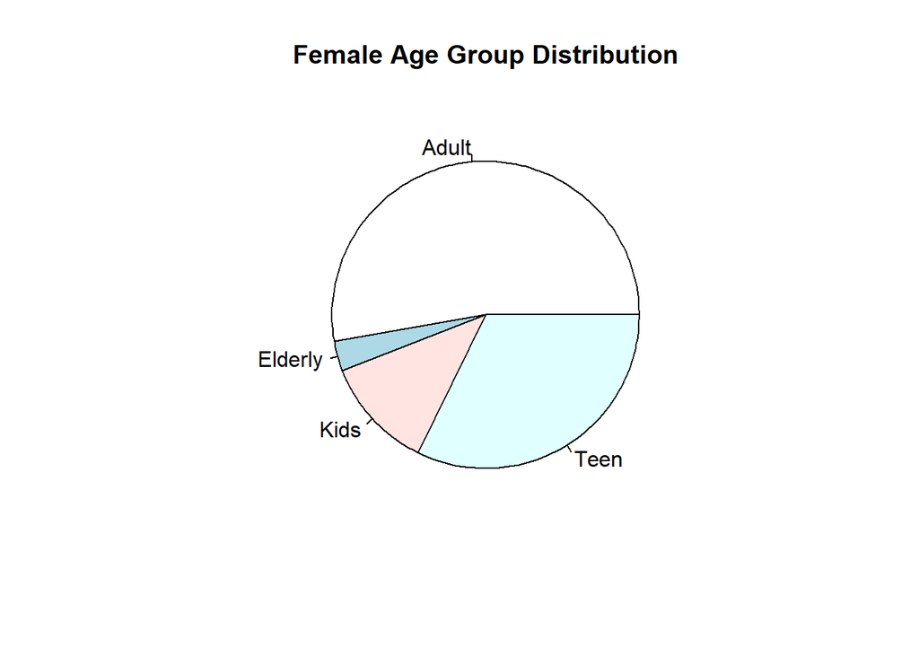

```r
pie(table(females$AgeGroup),main="Female Age Group Distribution")
```

Above are the visualization of Age Group distribution based one their Gender.

## 3.3 **Ticket Price Distribution**

```r
summary(passenger$Fare)
```

```
##    Min. 1st Qu.  Median    Mean 3rd Qu.    Max.    NA's
##   0.000   7.896  14.454  35.627  31.500 512.329       1
```

```r
var(passenger$Fare,na.rm=T)
```

```
## [1] 3125.657
```

```r
sum(passenger$Fare,na.rm=T)
```

```
## [1] 14856.54
```

As we can see above, the range between the most expensive and cheapest are very high. with the total sales being 14856.54

```r
Ticketing<-data.frame(xtabs(formula= Fare~Name,data=passenger))
head(Ticketing[order(-Ticketing$Freq),],10)
```

|  | Name | Freq |
| --- | --- | --- |
| 62 | Cardeza, Mrs. James Warburton Martinez (Charlotte Wardle Drake) | 512.3292 |
| 148 | Fortune, Miss. Ethel Flora | 263.0000 |
| 149 | Fortune, Mrs. Mark (Mary McDougald) | 263.0000 |
| 42 | Bowen, Miss. Grace Scott | 262.3750 |
| 72 | Chaudanson, Miss. Victorine | 262.3750 |
| 331 | Ryerson, Master. John Borie | 262.3750 |
| 332 | Ryerson, Mr. Arthur Larned | 262.3750 |
| 333 | Ryerson, Mrs. Arthur Larned (Emily Maria Borie) | 262.3750 |
| 123 | Douglas, Mrs. Frederick Charles (Mary Helene Baxter) | 247.5208 |
| 24 | Astor, Col. John Jacob | 227.5250 |

Above are the top ten list of passenger that paid the most expensive ticket price.

# 4 **Conclusion**